# Liver Disease Deep Learning Image Classification 2

## Context and Objective

This project builds a deep learning image classification model to detect liver disease from medical images. Using a custom CNN model, VGG16, and a third optimized model, we compare performance and adjust parameters to avoid Colab crashes (e.g., due to memory).

## Project Context

Liver disease classification through histopathological images is essential for early detection and treatment. This project compares three deep learning models to classify liver diseases effectively.

## Objective

To classify liver tissue images into multiple disease categories using:

- Model 1: Custom CNN
- Model 2: Transfer Learning using VGG16
- Model 3: Optimized VGG16 with GlobalAveragePooling

## Dataset Description

- Images are organized into subfolders by class.
- Training and testing sets are stored on Google Drive.
- Images are resized to 128x128 for computational efficiency.

## Import Libraries

```python
!pip install -q tensorflow

import tensorflow as tf
from tensorflow.keras.models import Sequential, Model
from tensorflow.keras.layers import Dense, Flatten, Dropout, Conv2D, MaxPooling2D, BatchNormalization, GlobalAveragePooling2D
from tensorflow.keras.preprocessing.image import ImageDataGenerator
from tensorflow.keras.applications import VGG16
from tensorflow.keras.applications.vgg16 import preprocess_input
import matplotlib.pyplot as plt
import numpy as np
import os
```

```python
from google.colab import drive
drive.mount('/content/drive')

train_dir = "/content/drive/MyDrive/My DS DA/Neural Networks (Deep Learning)/Image Classification/liver_disease/Training"
test_dir = "/content/drive/MyDrive/My DS DA/Neural Networks (Deep Learning)/Image Classification/liver_disease/Testing"
```

## Data Augmentation and Preprocessing

```python
train_datagen = ImageDataGenerator(
    rescale=1./255,
    horizontal_flip=True,
    rotation_range=15,
    zoom_range=0.1,
    width_shift_range=0.1,
    height_shift_range=0.1,
    validation_split=0.1
)

test_datagen = ImageDataGenerator(rescale=1./255)

train_generator = train_datagen.flow_from_directory(
    directory=train_dir,
    target_size=(128, 128),
    batch_size=16,
    class_mode='categorical',
    subset='training'
)

val_generator = train_datagen.flow_from_directory(
    directory=train_dir,
    target_size=(128, 128),
    batch_size=16,
    class_mode='categorical',
    subset='validation'
)

test_generator = test_datagen.flow_from_directory(
    directory=test_dir,
    target_size=(128, 128),
    batch_size=16,
    class_mode='categorical'
)
```

```
Found 2135 images belonging to 21 classes.
Found 236 images belonging to 21 classes.
Found 560 images belonging to 21 classes.
```

## Models

### Model 1: Custom CNN

Simple architecture with two Conv2D layers, used for baseline comparison.

```python
model1 = Sequential([
    Conv2D(32, (3, 3), activation='relu', input_shape=(128, 128, 3)),
    MaxPooling2D(2, 2),

    Conv2D(64, (3, 3), activation='relu'),
    MaxPooling2D(2, 2),

    Flatten(),
    Dense(64, activation='relu'),
    Dropout(0.3),
    Dense(train_generator.num_classes, activation='softmax')
])

model1.compile(optimizer='adam', loss='categorical_crossentropy', metrics=['accuracy'])
model1.summary()
```

```
Model: "sequential"
```

```
┏━━━━━━━━━━━━━━━━━━━━━━━━━━━━━━━━━━━━━━┳━━━━━━━━━━━━━━━━━━━━━━━━━━━━━┳━━━━━━━━━━━━━━━━━┓
┃ Layer (type)                         ┃ Output Shape                ┃         Param # ┃
┡━━━━━━━━━━━━━━━━━━━━━━━━━━━━━━━━━━━━━━╇━━━━━━━━━━━━━━━━━━━━━━━━━━━━━╇━━━━━━━━━━━━━━━━━┩
│ conv2d (Conv2D)                      │ (None, 126, 126, 32)        │             896 │
├──────────────────────────────────────┼─────────────────────────────┼─────────────────┤
│ max_pooling2d (MaxPooling2D)         │ (None, 63, 63, 32)          │               0 │
├──────────────────────────────────────┼─────────────────────────────┼─────────────────┤
│ conv2d_1 (Conv2D)                    │ (None, 61, 61, 64)          │          18,496 │
├──────────────────────────────────────┼─────────────────────────────┼─────────────────┤
│ max_pooling2d_1 (MaxPooling2D)       │ (None, 30, 30, 64)          │               0 │
├──────────────────────────────────────┼─────────────────────────────┼─────────────────┤
│ flatten (Flatten)                    │ (None, 57600)               │               0 │
├──────────────────────────────────────┼─────────────────────────────┼─────────────────┤
│ dense (Dense)                        │ (None, 64)                  │       3,686,464 │
├──────────────────────────────────────┼─────────────────────────────┼─────────────────┤
│ dropout (Dropout)                    │ (None, 64)                  │               0 │
├──────────────────────────────────────┼─────────────────────────────┼─────────────────┤
│ dense_1 (Dense)                      │ (None, 21)                  │           1,365 │
└──────────────────────────────────────┴─────────────────────────────┴─────────────────┘
```

```
 Total params: 3,707,221 (14.14 MB)
```

```
 Trainable params: 3,707,221 (14.14 MB)
```

```
 Non-trainable params: 0 (0.00 B)
```

```python
history1 = model1.fit(
    train_generator,
    validation_data=val_generator,
    epochs=5
)
```

```
134/134 ━━━━━━━━━━━━━━━━━━━━ 399s 3s/step - accuracy: 0.0616 - loss: 3.2881 - val_accuracy: 0.0636 - val_loss: 2.8399
134/134 ━━━━━━━━━━━━━━━━━━━━ 73s 540ms/step - accuracy: 0.0624 - loss: 2.8819 - val_accuracy: 0.1017 - val_loss: 2.7277
134/134 ━━━━━━━━━━━━━━━━━━━━ 70s 525ms/step - accuracy: 0.1198 - loss: 2.6946 - val_accuracy: 0.1610 - val_loss: 2.5570
134/134 ━━━━━━━━━━━━━━━━━━━━ 73s 540ms/step - accuracy: 0.1312 - loss: 2.6247 - val_accuracy: 0.1949 - val_loss: 2.4608
134/134 ━━━━━━━━━━━━━━━━━━━━ 72s 538ms/step - accuracy: 0.1834 - loss: 2.5143 - val_accuracy: 0.2669 - val_loss: 2.2105
```

### Model 2: VGG16 Transfer Learning

Pre-trained VGG16 as feature extractor, dense layers added for classification.

```python
vgg = VGG16(weights='imagenet', include_top=False, input_shape=(128, 128, 3))
for layer in vgg.layers:
    layer.trainable = False

model2 = Sequential([
    vgg,
    Flatten(),
    Dense(128, activation='relu'),
    Dropout(0.3),
    Dense(train_generator.num_classes, activation='softmax')
])

model2.compile(optimizer='adam', loss='categorical_crossentropy', metrics=['accuracy'])
model2.summary()
```

```
Downloading data from https://storage.googleapis.com/tensorflow/keras-applications/vgg16/vgg16_weights_tf_dim_ordering_tf_kernels_notop.h5
58889256/58889256 ━━━━━━━━━━━━━━━━━━━━ 0s 0us/step
```

```
Model: "sequential_1"
```

```
┏━━━━━━━━━━━━━━━━━━━━━━━━━━━━━━━━━━━━━━┳━━━━━━━━━━━━━━━━━━━━━━━━━━━━━┳━━━━━━━━━━━━━━━━━┓
┃ Layer (type)                         ┃ Output Shape                ┃         Param # ┃
┡━━━━━━━━━━━━━━━━━━━━━━━━━━━━━━━━━━━━━━╇━━━━━━━━━━━━━━━━━━━━━━━━━━━━━╇━━━━━━━━━━━━━━━━━┩
│ vgg16 (Functional)                   │ (None, 4, 4, 512)           │      14,714,688 │
├──────────────────────────────────────┼─────────────────────────────┼─────────────────┤
│ flatten_1 (Flatten)                  │ (None, 8192)                │               0 │
├──────────────────────────────────────┼─────────────────────────────┼─────────────────┤
│ dense_2 (Dense)                      │ (None, 128)                 │       1,048,704 │
├──────────────────────────────────────┼─────────────────────────────┼─────────────────┤
│ dropout_1 (Dropout)                  │ (None, 128)                 │               0 │
├──────────────────────────────────────┼─────────────────────────────┼─────────────────┤
│ dense_3 (Dense)                      │ (None, 21)                  │           2,709 │
└──────────────────────────────────────┴─────────────────────────────┴─────────────────┘
```

```
 Total params: 15,766,101 (60.14 MB)
```

```
 Trainable params: 1,051,413 (4.01 MB)
```

```
 Non-trainable params: 14,714,688 (56.13 MB)
```

```python
history2 = model2.fit(
    train_generator,
    validation_data=val_generator,
    epochs=5
)
```

```
134/134 ━━━━━━━━━━━━━━━━━━━━ 501s 4s/step - accuracy: 0.1860 - loss: 2.7849 - val_accuracy: 0.3686 - val_loss: 1.9885
134/134 ━━━━━━━━━━━━━━━━━━━━ 532s 4s/step - accuracy: 0.3274 - loss: 2.0610 - val_accuracy: 0.4364 - val_loss: 1.6605
134/134 ━━━━━━━━━━━━━━━━━━━━ 525s 4s/step - accuracy: 0.4095 - loss: 1.7817 - val_accuracy: 0.5042 - val_loss: 1.5360
134/134 ━━━━━━━━━━━━━━━━━━━━ 524s 4s/step - accuracy: 0.4359 - loss: 1.6751 - val_accuracy: 0.5339 - val_loss: 1.4659
134/134 ━━━━━━━━━━━━━━━━━━━━ 492s 4s/step - accuracy: 0.4949 - loss: 1.5143 - val_accuracy: 0.5763 - val_loss: 1.3456
```

- Model 2 significantly outperforms Model 1. The pretrained VGG16 backbone improves feature learning, showing stronger generalization. A solid baseline for further tuning.
- Final Training Accuracy: 49.5%
- Final Validation Accuracy: 57.6%
- Loss Trend: Both training and validation loss decreased steadily (train: 2.78 → 1.51, val: 1.99 → 1.34)

### Model 3: Optimized VGG16

Same VGG16 base with GlobalAveragePooling and dropout for optimization.

```python
model3 = Sequential([
    vgg,
    GlobalAveragePooling2D(),
    Dense(128, activation='relu'),
    Dropout(0.3),
    Dense(train_generator.num_classes, activation='softmax')
])

model3.compile(optimizer='adam', loss='categorical_crossentropy', metrics=['accuracy'])
model3.summary()
```

```
Model: "sequential_2"
```

```
┏━━━━━━━━━━━━━━━━━━━━━━━━━━━━━━━━━━━━━━┳━━━━━━━━━━━━━━━━━━━━━━━━━━━━━┳━━━━━━━━━━━━━━━━━┓
┃ Layer (type)                         ┃ Output Shape                ┃         Param # ┃
┡━━━━━━━━━━━━━━━━━━━━━━━━━━━━━━━━━━━━━━╇━━━━━━━━━━━━━━━━━━━━━━━━━━━━━╇━━━━━━━━━━━━━━━━━┩
│ vgg16 (Functional)                   │ (None, 4, 4, 512)           │      14,714,688 │
├──────────────────────────────────────┼─────────────────────────────┼─────────────────┤
│ global_average_pooling2d             │ (None, 512)                 │               0 │
│ (GlobalAveragePooling2D)             │                             │                 │
├──────────────────────────────────────┼─────────────────────────────┼─────────────────┤
│ dense_4 (Dense)                      │ (None, 128)                 │          65,664 │
├──────────────────────────────────────┼─────────────────────────────┼─────────────────┤
│ dropout_2 (Dropout)                  │ (None, 128)                 │               0 │
├──────────────────────────────────────┼─────────────────────────────┼─────────────────┤
│ dense_5 (Dense)                      │ (None, 21)                  │           2,709 │
└──────────────────────────────────────┴─────────────────────────────┴─────────────────┘
```

```
 Total params: 14,783,061 (56.39 MB)
```

```
 Trainable params: 68,373 (267.08 KB)
```

```
 Non-trainable params: 14,714,688 (56.13 MB)
```

```python
history3 = model3.fit(
    train_generator,
    validation_data=val_generator,
    epochs=5
)
```

```
134/134 ━━━━━━━━━━━━━━━━━━━━ 525s 4s/step - accuracy: 0.1432 - loss: 2.7888 - val_accuracy: 0.3559 - val_loss: 2.1997
134/134 ━━━━━━━━━━━━━━━━━━━━ 490s 4s/step - accuracy: 0.3181 - loss: 2.2245 - val_accuracy: 0.4153 - val_loss: 1.9489
134/134 ━━━━━━━━━━━━━━━━━━━━ 500s 4s/step - accuracy: 0.3765 - loss: 2.0033 - val_accuracy: 0.4237 - val_loss: 1.8297
134/134 ━━━━━━━━━━━━━━━━━━━━ 493s 4s/step - accuracy: 0.4082 - loss: 1.8610 - val_accuracy: 0.3941 - val_loss: 1.7524
134/134 ━━━━━━━━━━━━━━━━━━━━ 488s 4s/step - accuracy: 0.4288 - loss: 1.7693 - val_accuracy: 0.5169 - val_loss: 1.6022
```

## Results

### Accuracy Comparison Plot

Compare training and validation accuracy of all three models.

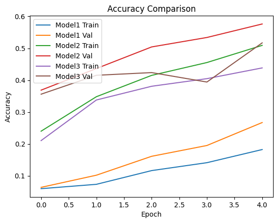

```python
plt.plot(history1.history['accuracy'], label='Model1 Train')
plt.plot(history1.history['val_accuracy'], label='Model1 Val')
plt.plot(history2.history['accuracy'], label='Model2 Train')
plt.plot(history2.history['val_accuracy'], label='Model2 Val')
plt.plot(history3.history['accuracy'], label='Model3 Train')
plt.plot(history3.history['val_accuracy'], label='Model3 Val')
plt.title('Accuracy Comparison')
plt.xlabel('Epoch')
plt.ylabel('Accuracy')
plt.legend()
plt.show()
```

- It consistently outperforms others across all epochs in both training and validation performance
- Model 2 (VGG16) shows the highest and most stable accuracy on both training and validation datasets.
- Model 3 performs decently but slightly below Model 2.
- Model 1 (Custom CNN) lags behind significantly in both training and validation accuracy.

### Final Evaluation

Evaluate final model on unseen test data.

```python
loss, acc = model3.evaluate(test_generator)
print(f"Model 3 Test Accuracy: {acc:.2f}")
```

```
35/35 ━━━━━━━━━━━━━━━━━━━━ 117s 3s/step - accuracy: 0.4033 - loss: 1.8408
Model 3 Test Accuracy: 0.43
```

Accuracy & Loss Curves

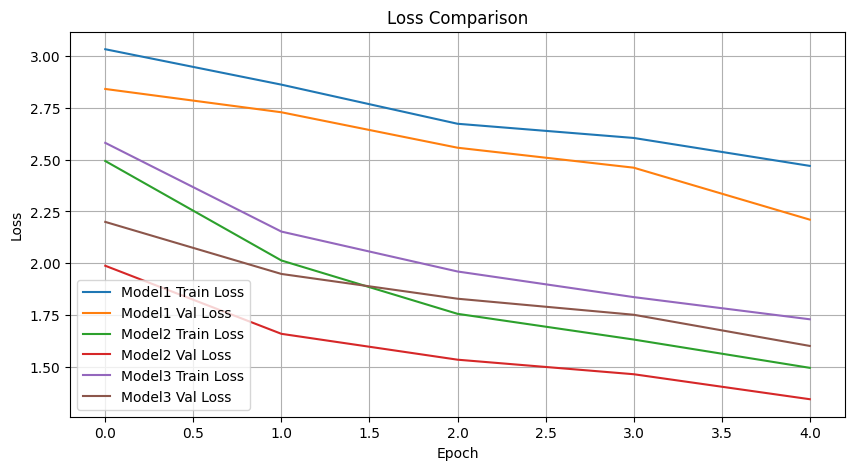

```python
# Plot Loss
plt.figure(figsize=(10, 5))
plt.plot(history1.history['loss'], label='Model1 Train Loss')
plt.plot(history1.history['val_loss'], label='Model1 Val Loss')
plt.plot(history2.history['loss'], label='Model2 Train Loss')
plt.plot(history2.history['val_loss'], label='Model2 Val Loss')
plt.plot(history3.history['loss'], label='Model3 Train Loss')
plt.plot(history3.history['val_loss'], label='Model3 Val Loss')
plt.title('Loss Comparison')
plt.xlabel('Epoch')
plt.ylabel('Loss')
plt.legend()
plt.grid(True)
plt.show()
```

- Best Model Based on Loss: Model 2 – VGG16
  - Lowest and most consistent loss across epochs.
- Model 2 (VGG16) shows the lowest loss for both training and validation, indicating better generalization.
- Model 3 follows closely behind, performing better than Model 1 but not as well as Model 2.
- Model 1 has the highest loss, indicating it struggles more with learning and generalizing.

Confusion Matrix (per-class performance)

```
35/35 ━━━━━━━━━━━━━━━━━━━━ 117s 3s/step
```

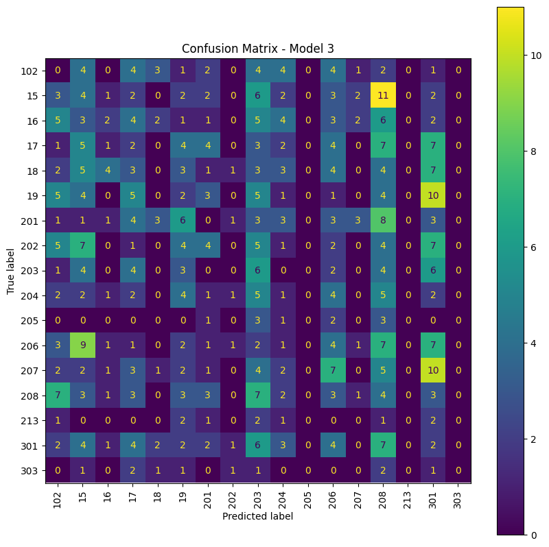

```python
from sklearn.metrics import confusion_matrix, ConfusionMatrixDisplay
import numpy as np
import matplotlib.pyplot as plt

# Predict classes for Model 3
y_pred = model3.predict(test_generator)
y_pred_classes = np.argmax(y_pred, axis=1)

# True labels
y_true = test_generator.classes

# Only keep class names that appear in test set
used_class_indices = sorted(np.unique(y_true))
used_class_names = [class_names[i] for i in used_class_indices]

# Confusion matrix
cm = confusion_matrix(y_true, y_pred_classes, labels=used_class_indices)

# Plot it
fig, ax = plt.subplots(figsize=(10, 10))
disp = ConfusionMatrixDisplay(confusion_matrix=cm, display_labels=used_class_names)
disp.plot(ax=ax, xticks_rotation='vertical')
plt.title("Confusion Matrix - Model 3")
plt.grid(False)
plt.show()
```

Classification Report

```python
from sklearn.metrics import classification_report
import numpy as np

# Get only labels that exist in test set
labels = sorted(np.unique(y_true))
label_names = [class_names[i] for i in labels]

# Generate classification report
print(classification_report(y_true, y_pred_classes, labels=labels, target_names=label_names))
```

[output not shown]

## Conclusion and Recommendations

Recommendation:

```python
# path_ipynb = '/content/drive/MyDrive/My DS DA/Neural Networks (Deep Learning)/Image Classification/Liver Disease Deep learning image Classification 2.ipynb'

# notebook_path = path_ipynb

# !jupyter nbconvert --to html "{notebook_path}"

# from google.colab import files

# path_html = '/content/drive/MyDrive/My DS DA/Neural Networks (Deep Learning)/Image Classification/Liver Disease Deep learning image Classification 2.html'

# files.download(path_html)
```

[output not shown]